# 第8回 クラスタリング：k-meansと階層的クラスタリング

## 3つの群を見る

4節 ⑧ シルエット●●●●●●

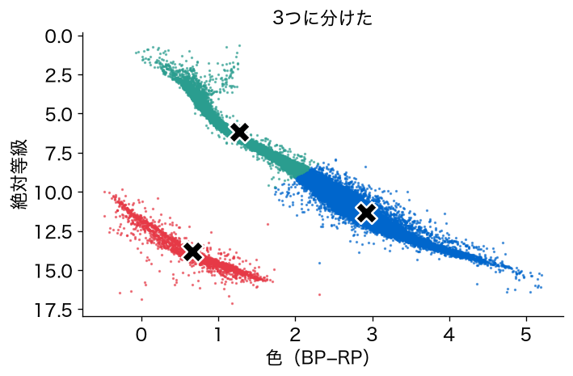

- 白色矮星が1つの群。主系列は、明るい側と暗い側に切られている

## お手本：星ごとのシルエット

4節 ⑨ シルエット図●○○

```python
from sklearn.metrics import silhouette_samples
rng = np.random.default_rng(0)
idx = rng.choice(len(X), 3000, replace=False)
lab3 = KMeans(3, n_init=10, random_state=0).fit_predict(X)[idx]
s3 = silhouette_samples(X[idx], lab3)
for g in range(3):
    print(g, (lab3 == g).sum(), round(s3[lab3 == g].mean(), 3))
```

```
0 2015 0.642
1 215 0.698
2 770 0.579
```

## 1行ずつ：星ごとのシルエット

4節 ⑨ シルエット図●●○

```python
from sklearn.metrics import silhouette_samples
rng = np.random.default_rng(0)
idx = rng.choice(len(X), 3000, replace=False)
lab3 = KMeans(3, n_init=10, random_state=0).fit_predict(X)[idx]
s3 = silhouette_samples(X[idx], lab3)
for g in range(3):
    print(g, (lab3 == g).sum(), round(s3[lab3 == g].mean(), 3))
```

- 1〜3行目：星ごとのシルエットを出す道具を呼び、3,000個を抜き出す（全部だと重い）
- 4・5行目：3つに分けた群の番号のうち、抜き出した星の分を取り、星ごとのシルエットを出す
- 6・7行目：群ごとに、星の数とシルエットの平均を表示する

## シルエット図

4節 ⑨ シルエット図●●●

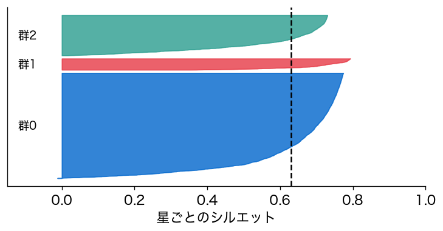

- 群ごとに、星のシルエットを大きい順に並べた。点線が全体の平均
- 白色矮星の群1（215個）が0.698でいちばんまとまる。主系列を輪切りにした群2（770個）は0.579

## 重要：指針も距離で測る

4節 10 シルエット●

群の数の指針は、数を1つ出してくれる。でも、その指針もk-meansと同じ距離の物差しで測っている。最後は、群の中身を読んで決める。

## TODO③：群の数の範囲を替える

4節 11 範囲を替える●○

```python
# TODO: 9 を 13 に替えて実行する（少し時間がかかる）
rng = np.random.default_rng(0)
gaps_x = []
for k in range(1, 9):
    fake_w = []
    for b in range(5):
        fake = rng.uniform(X.min(axis=0), X.max(axis=0), size=X.shape)
        fake_w.append(log_w(fake, k))
    gaps_x.append(np.mean(fake_w) - log_w(X, k))
print(np.round(gaps_x, 3))
```

- 予想：12まで増やすと、Gapはどこかで伸びが止まるか

## ここまでで分かったこと

4節 11 範囲を替える●●

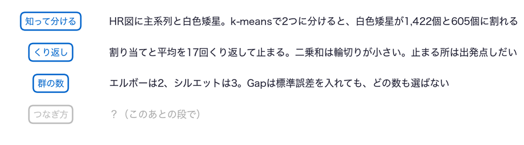

- まだ分からないのは、細長い帯を、帯のまま1つの群にできるか

## ノートへ：4節

4節 12 ノートへ●

- 4節のセルを上から実行し、スライドと同じ数が出るか確かめる
- TODO③：予想を書く → `9`を`13`に替えて実行 → 予想と比べる

動画の人は、ここで一時停止。

## 答え合わせ：TODO③

4節 13 答え合わせ●

```
[1.016 1.387 1.468 1.617 1.872 2.006 2.06  2.095 2.16  2.254 2.307 2.338]
```

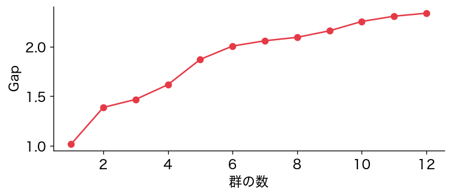

- 12まで増やしても、Gapは伸び続ける。主系列は、いくらでも細かく切れる

# 5. 帯のまま分けられる？

## 段4：つなぎ方を替える

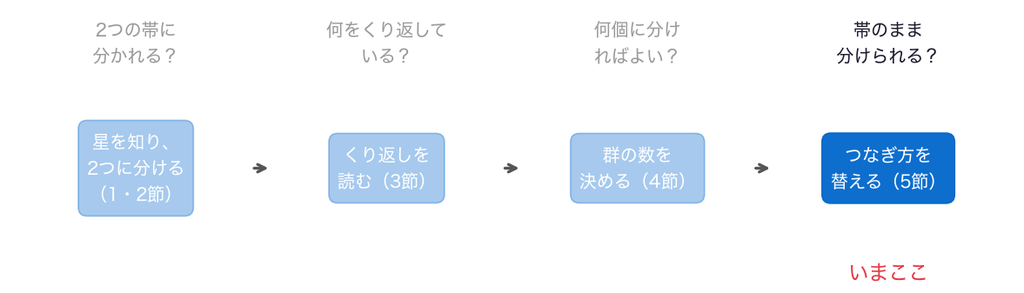

- 問い：細長い帯を、帯のまま1つの群にできるか

## 前の段から

- k-meansは、中心までの距離の二乗和を小さくするので、長い主系列を輪切りにする
- 群の数の指針も、同じ物差しで測っている。Gapは止まらなかった
- 群の数ではなく、何を「近い」と見るか、そのものを替えてみる

## 階層的クラスタリング

5節 ① 階層●○○

- はじめは、星1つずつが1つの群
- いちばん近い2つの群を、1つにつなぐ。これを、全部が1つになるまでくり返す
- つないだ順番を木の形に描いたものを、樹形図（デンドログラム）という

## 小さな例：6つの星

5節 ① 階層●●○

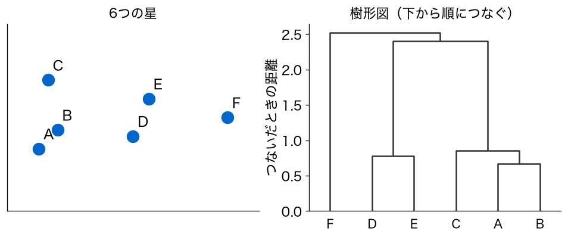

- 近いAとBが最初につながる。樹形図の高さは、つないだときの距離

## 樹形図を切ると、群になる

5節 ① 階層●●●

- 樹形図を、ある高さで横に切ると、その下につながった塊が群になる
- 6つの星の例を、いちばん上の手前で切ると、A〜EとFの2つ
- 群の数を先に決めなくても、樹形図を見てから決められる

## つなぎ方

5節 ② つなぎ方●

- 群と群の近さを、どう測るかを決める必要がある。これをつなぎ方という
- 単連結：2つの群の中で、いちばん近い星どうしの距離
- ウォード法：つないだとき、中心までの二乗和がどれだけ増えるか（k-meansと同じ物差し）

## 3,000個を抜き出す

5節 ③ 抜き出す●○○

- 階層的クラスタリングは、すべての星の組の距離を使う
- 27,860個だと、組は約3億9千万。Colabでは重い
- でたらめに3,000個を選んで分ける

## お手本：3,000個を抜き出す

5節 ③ 抜き出す●●○

```python
rng = np.random.default_rng(0)
idx = rng.choice(len(df), 3000, replace=False)
sub = df.iloc[idx]
Xs = X[idx]
print(len(sub), sub['白色矮星'].sum())
```

```
3000 215
```

## 1行ずつ：3,000個を抜き出す

5節 ③ 抜き出す●●●

```python
rng = np.random.default_rng(0)
idx = rng.choice(len(df), 3000, replace=False)
sub = df.iloc[idx]
Xs = X[idx]
print(len(sub), sub['白色矮星'].sum())
```

- 1・2行目：乱数の道具をシード0で用意し、星の番号を、重ならないように（`replace=False`）3,000個選ぶ
- 3・4行目：選んだ番号の行の表`sub`と、標準化した値`Xs`
- 5行目：星の数と、その中の白色矮星の数（215個）

## お手本：単連結で2つに分ける

5節 ④ 単連結●○○○

```python
from sklearn.cluster import AgglomerativeClustering
ag = AgglomerativeClustering(2, linkage='single')
lab_s = ag.fit_predict(Xs)
pd.crosstab(sub['白色矮星'], lab_s)
```

| col_0 白色矮星 | 0 | 1 |
| --- | --- | --- |
| 0 | 0 | 2785 |
| 1 | 215 | 0 |

## 1行ずつ：単連結で2つに分ける

5節 ④ 単連結●●○○

```python
from sklearn.cluster import AgglomerativeClustering
ag = AgglomerativeClustering(2, linkage='single')
lab_s = ag.fit_predict(Xs)
pd.crosstab(sub['白色矮星'], lab_s)
```

- 1・2行目：階層的クラスタリングの道具を呼び出し、群の数2、つなぎ方は単連結（`single`）で準備する
- 3行目：つないでいき、2つの群になったところで止めて、群の番号を出す
- 4行目：目安の線（1が白色矮星）と、群の番号を突き合わせる（2節と同じ）

## 中身を見る：群ごとの星の数

5節 ④ 単連結●●●○

```python
print(np.bincount(lab_s))
```

```
[ 215 2785]
```

- `bincount`は、番号0・1ごとの数。215個と2,785個。目安の線の数と同じ

## えっ、帯のまま分かれた

5節 ④ 単連結●●●●

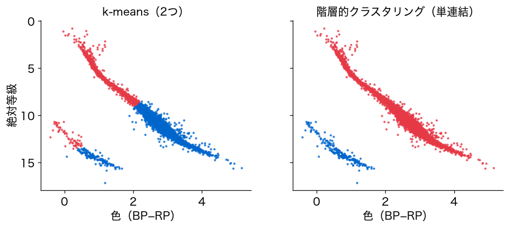

- 同じ3,000個で、k-meansは白色矮星を割り、単連結は主系列と白色矮星をそのまま分けた

## なぜ分かれる？

5節 ⑤ 鎖●

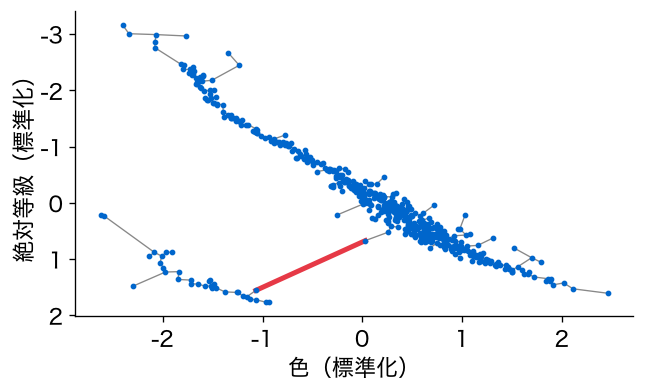

- 単連結は、隣の星から隣の星へ、鎖のようにつなぐ。帯の中はすき間が小さいので、1本の鎖になる
- 2つの帯のあいだのすき間（赤）だけが大きく、最後までつながらない

## お手本：樹形図を描く

5節 ⑥ 樹形図●○○

```
[0.353 0.462 1.323]
```

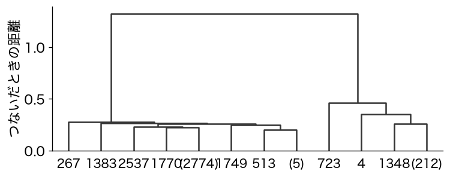

```python
from scipy.cluster.hierarchy import linkage, dendrogram
Z = linkage(Xs, 'single')
print(Z[-3:, 2].round(3))
dendrogram(Z, truncate_mode='lastp', p=12)
plt.ylabel('つないだときの距離')
plt.show()
```

## 1行ずつ：樹形図を描く

5節 ⑥ 樹形図●●○

```python
from scipy.cluster.hierarchy import linkage, dendrogram
Z = linkage(Xs, 'single')
print(Z[-3:, 2].round(3))
dendrogram(Z, truncate_mode='lastp', p=12)
plt.ylabel('つないだときの距離')
plt.show()
```

- 1・2行目：樹形図の道具を呼び、単連結でつないだ順番と距離を`Z`にしまう（1行が1回のつなぎ）
- 3行目：最後の3回のつなぎの距離（`Z`の3列目）
- 4〜6行目：樹形図を描く。`truncate_mode='lastp', p=12`は、上の12本だけを描く指定

## 最後のつなぎだけが高い

5節 ⑥ 樹形図●●●

## お手本：ウォード法の樹形図

5節 ⑦ 樹形図で数を読む●○

```
[24.  42.9 50.6 74.5]
```

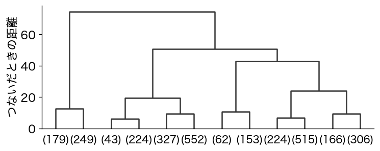

```python
Zw = linkage(Xs, 'ward')
print(Zw[-4:, 2].round(1))
dendrogram(Zw, truncate_mode='lastp', p=12)
plt.ylabel('つないだときの距離')
plt.show()
```

## 樹形図で群の数を読む

5節 ⑦ 樹形図で数を読む●●

## 単連結の弱点

5節 ⑧ 弱点●

```python
lab_s3 = AgglomerativeClustering(3, linkage='single').fit_predict(Xs)
print(np.bincount(lab_s3))
```

```
[ 214 2785    1]
```

- 3つに分けると、離れた星1個だけの群ができる。単連結は、離れた点を1つずつ切り出しやすい

## えっ、シルエットは輪切りを選ぶ

5節 ⑨ シルエットで比べる●○

```python
from sklearn.metrics import silhouette_score
print(round(silhouette_score(Xs, lab_s), 3))
print(round(silhouette_score(Xs, df['群'].values[idx]), 3))
```

```
0.48
0.563
```

- 1行目：帯のまま分けた単連結。2行目：同じ3,000個の、k-meansの2つの群（2節の列「群」）
- 帯のまま分けた単連結は0.48、輪切りのk-meansは0.563。シルエットは、輪切りのほうを「良い」と言う

## なぜ？：シルエットも丸い群びいき

5節 ⑨ シルエットで比べる●●

- シルエットは、同じ群の星までの距離の平均（$a$）と、となりの群までの距離の平均（$b$）で測る
- 細長い帯では、帯の端の星は、同じ帯の反対の端から遠い。$a$が大きくなり、シルエットは低く出る
- 群の数の指針も、群の良さの指針も、中心や平均の距離で測る。帯のような群は、低く見積もられる

## 重要：何を近いと見るか

5節 10 弱点●

群と群の近さを、中心までの二乗和で測るか、いちばん近い星どうしで測るかで、見つかる群が変わる。帯のような群は、つながりで測ると帯のまま分かれる。

## TODO④：つなぎ方を替える

5節 11 つなぎ方を替える●○

```python
# TODO: 'single' を 'ward' に替えて実行する
ag_x = AgglomerativeClustering(2, linkage='single')
lab_x = ag_x.fit_predict(Xs)
pd.crosstab(sub['白色矮星'], lab_x)
```

- `'ward'`は、k-meansと同じ二乗和の物差しでつなぐ
- 予想：ウォード法でも、主系列と白色矮星に分かれるか

## ここまでで分かったこと

5節 11 つなぎ方を替える●●

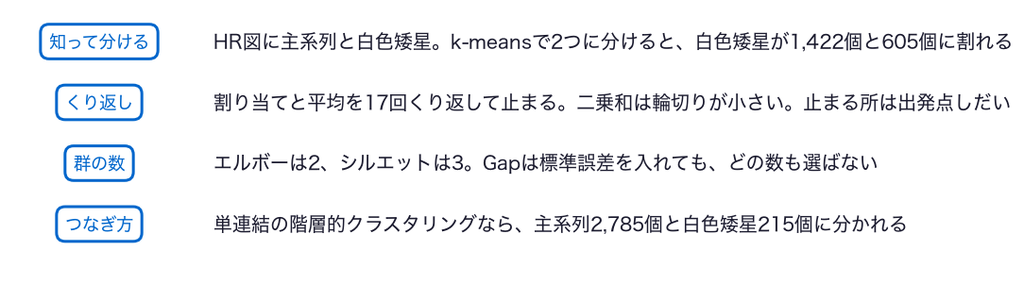

- 4つの段がそろい、今日の問いに答えられる

## ノートへ：5節

5節 12 ノートへ●

- 5節のセルを上から実行し、スライドと同じ数が出るか確かめる
- TODO④：予想を書く → `'single'`を`'ward'`に替えて実行 → 予想と比べる

動画の人は、ここで一時停止。

## 答え合わせ：TODO④

5節 13 答え合わせ●

```
col_0     0    1
白色矮星
0      2357  428
1       215    0
```

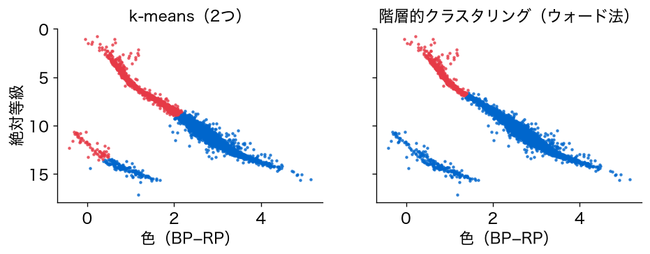

- ウォード法では、白色矮星は主系列の暗い側と同じ群に入り、明るい側の428個が切り出される
- 二乗和の物差しに戻すと、帯は帯のままにならない

## 答え：k-meansでは分かれない

5節 14 答え●

- k-meansで2つに分けると、主系列と白色矮星には分かれない。中心までの二乗和を小さくするので、長い主系列を輪切りにする
- 群の数は、エルボー法なら2、シルエットなら3。Gapは規則を入れても選ばない。指針ごとに答えが違う
- 近い星どうしをつなぐ階層的クラスタリング（単連結）なら、2つの帯がそのまま分かれる

## まだ言えないこと

5節 15 まだ言えないこと●

- 階層的クラスタリングは3,000個で試した。全部の星では、帯のあいだにも星が入り、鎖がつながってしまうことがある
- 2つの帯の境目にある星を、どちらの群とも言い切らない扱い
- 指針どうしが食い違ったとき、どれを信じるか

# まとめ

## 今日の道筋を振り返る

⑨ 振り返る●○○○

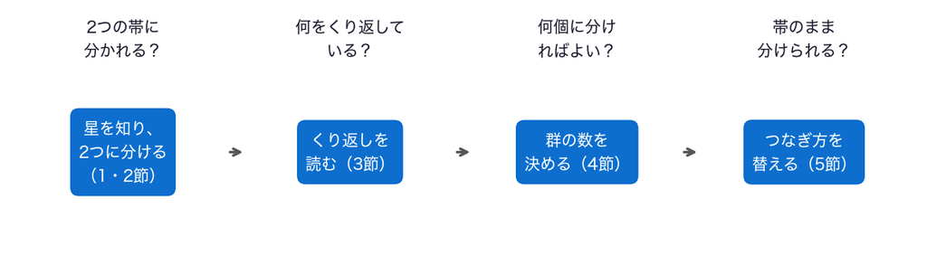

- HR図を描き、k-meansで分け、中のくり返しと止まる所を読み、群の数の指針を並べ、つなぎ方を替えた

## 今日持ち帰る1文

⑨ 振り返る●●○○

k-meansは、近い中心に割り当てて中心を平均へ動かすことを、動かなくなるまでくり返す。距離の二乗和を小さくするので、丸い群を探し、細長い群は輪切りにする。近い星どうしをつなぐ階層的クラスタリングなら、帯は帯のまま分かれる。

## 今日の重要概念

⑨ 振り返る●●●○

統計：k-meansは、中心までの距離の二乗和を小さくする分け方を探す。だから丸くまとまった群を好み、細長い群は輪切りにする。

Python：whileは、条件を満たすあいだ、くり返す。何回で終わるかが先に決まらないくり返しに使う。

## 今日の要点

⑨ 振り返る●●●●

- 距離で分ける前に、列の単位をそろえる（標準化）
- 群の数の指針は目安。指針も距離の物差しの上に立つ
- 何を「近い」と見るか（つなぎ方）を替えると、見つかる群が変わる

## レポートなら、こう書く①

10 レポートなら●○

- 予想：2つに分ければ、主系列と白色矮星に分かれるだろう
- 解析：色と絶対等級を標準化し、k-meansで2つに分けた
- 驚き：白色矮星が2つの群に割れた。目安の線と比べると、1,422個と605個

## レポートなら、こう書く②

10 レポートなら●●

- 理由：見た目どおりの分け方は、二乗和が45,877で、輪切り（24,035）の2倍近い
- 群の数：エルボーは2、シルエットは3が最大、Gapは揺れの規則でも選ばない。3つの群の中身を読んで決めた
- 別の方法：単連結の階層的クラスタリングなら、3,000個で主系列2,785個と白色矮星215個にぴったり分かれた

## 課題の出し方

11 このあと●○○

- 今日の重要概念は、統計の「k-meansは丸い群を探す」と、Pythonの`while`
- 2つを1枚ずつ絵にし、2枚をLACSに提出（＝出席。期限なし）
- 手描きの写真でも、描画アプリでもよい。上手でなくてよい

## 次回の問い

11 このあと●●○

- 今日のk-meansと階層的クラスタリングは、星を1つの群に言い切った
- 群の形が楕円でもよく、境目の星を「どちらの群か、確率で」言える分け方はあるか

## このあと：課題へ

11 このあと●●●

- ノートの最後の「課題（提出）」を開く
- 絵を描き終えたら、このあとの「解答」で、絵の例と見比べる

# ここから先は解答

## 課題のあとで見る

- ここから先は、課題の絵を描き終えてから見る
- 絵の例を2つ見せる。上手さではなく、考えが伝わるかを見比べる

## 絵の例：k-meansは丸い群を探す

- 細長い商店街に、売店を2つ置く。客は、いちばん近い売店へ行く
- 売店は、客の多いところへ少しずつ動く
- すると商店街は、真ん中で2つに切られる。通りの東と西という「見た目の2つ」とは、限らない

## 絵の例：while

- お風呂にお湯を足していく
- 「ぬるいあいだは、足す」。何杯で終わるかは、やってみるまで分からない
- ちょうどよくなったら、止める

# 発展（任意）

## 出発点を賢く選ぶ

- 3節の`init='random'`は、星をでたらめに選んで出発点にした
- `KMeans`の決まりの選び方（k-means++）は、互いに離れた星を選びやすくする
- 同じ20通りで、いちばん小さい二乗和に届く回数を比べる

## お手本：k-means++で20通り

```python
ss_pp = []
for s in range(20):
    km_s = KMeans(3, n_init=1, random_state=s)
    km_s.fit(X)
    ss_pp.append(round(km_s.inertia_))
print(min(ss_pp), ss_pp.count(min(ss_pp)))
```

```
14038 11
```

## 選び方で、届く回数が変わる

- `init`を書かないと、k-means++になる。20回のうち11回が、いちばん小さい二乗和14038に届いた
- でたらめ（2回）より、ずっと多い。それでも全部ではないので、`n_init`で何通りも試す
- 試すなら、群の数を4や5にして、届く回数を比べる

## おわり

- お疲れさまでした